# Investigating Inequality with Real-Life Data

## Overview

## Who am I?

- A PhD Candidate
- A Political Scientist
- A Methodologist
- A nerd.

[figure not shown]

## What Shall We Discuss?

How to conduct a political scientific research?

- Taking inequality as an example.
  - Informational: not very much.
  - Practical: Yeah!
- Two parts:
  - Strategy
  - Method

Two examples

[1] Frederick Solt, Yue Hu, Kevan Hudson, et al. “Economic Inequality and Class Consciousness”. In: *Journal of Politics* 3 (2017). Forthcoming.

[2] Frederick Solt, Yue Hu, Kevan Hudson, et al. “Economic Inequality and Belief in Meritocracy in the United States”. In: *Research and Politics* 3.4 (2016), pp. 1-7.

- READY TO START?

[figure not shown]

## Well…Some stretching first?

[figure not shown]

## Strategies

## What's My Topic?

- Inequality. Yes.
  - Where does it come from?
- Where do most questions come from?
  - Some deep thoughts?
    - Nope.
  - Some personal experience?
    - Nope.
  - Movie, TV, music?
    - Probably, but nope.

Where should you look for?

- Some other paper, e.g., Solt et al. 2017.
- Term paper, e.g., Solt et al. 2016.

## Question, Question…

- What's a good question? (KKV 1994)
  - Important
  - Potentially failed
  - Ignored or misunderstood

## Pratical Rules

- Powerful
  - Curious
  - General
  - Falsified
- Attractive
  - Mind-blowing
  - Simple
  - Punchy

## Example: Solt et al. 2017

- Low-income group \(\rightarrow\) Income inequality \(\rightarrow\) Class consciousness

[figure not shown]

  - Self-correction?
  - Spiritual or material?

## Example: Solt et al. 2016

- Low-income group \(\rightarrow\) Income inequality \(\rightarrow\) Meritocracy
  - Meritocracy

[figure not shown]

  - Poor vs. Rich
  - Social Structure: Self-reproducing vs. self-negating

## So, does your research question like her/him?

[figure not shown]

## Where Are You, My Research Question?

- Office hours
- Literature
- Chat

## Theory or Myth?

- What's a theory?
- Something like this?

[figure not shown]

- Yes, and no.

## A Good Theory

- Not have to be complicate
- Not have to be detailed
- Not have to be static

## Principles

- Scientific (Popper 1968)
  - Consistent
  - Falsifiable
- Valid
  - Unit of Analysis
  - Causal inference
- General
  - General terms
  - Avoid stretching

## Example: Solt et al. 2017

- Situational trigger
  - Economic comparison
  - Relative economic position
- Low-income group \(\rightarrow\) More income inequality \(\rightarrow\) More class consciousness

[figure not shown]

## Example: Solt et al. 2016

- Conflict theory (Brady 2004; Oliver 2001)
  - Inequality \(\rightarrow\) awakening \(\rightarrow\) fight for redistribution

[figure not shown]

- Relative power theory (Solt 2010)
  - Money = political source
  - The riches teach the poor

[figure not shown]

## Theoretical \(\rightarrow\) Opertional

- Rule of building a causal theory (KKV 1994)
  - Falsifiable
  - Consistent
  - Variance in the dependent variable
  - Concrete
  - Feasible
- How to show these in your paper?
  - Hypotheses
  - Measurement

## Hypotheses

- Logical rather than descriptive or normative statement
- Clear relationship
- Small set
- Fuzzy-set test (Mahoney 2001)
- KEY: Straightforward

[figure not shown]

## Example:

- Solt et al. 2017: Poor people living with high inequality regard themselves more/less as "have-not."
- Solt et al. 2016: Poor people living with high inequality believe in meritocracy more/less.

## Measurement

- Internal Validity
  - Construct validity
  - Causal validity
  - Statistical validity
- External Validity
  - Scientific replication
- Ecological Validity
- Coding rule: unbiased and efficient

## Example: Meritocracy

- Newman, Johnston, and Lown (2015): Pew data
  - 2005-06:
    - "Most people who want to get ahead can make it if they’re willing to work hard."
    - "Hard work and determination are no guarantee of success for most people."
  - 2007: four-point agree-disagree
    - "Hard work offers little guarantee of success."
    - "Success in life is pretty much determined by forces outside our control."
  - 2009: four-point agree-disagree
    - "Hard work offers little guarantee of success."

## What's the problem?

- Not all data
- Selected method.

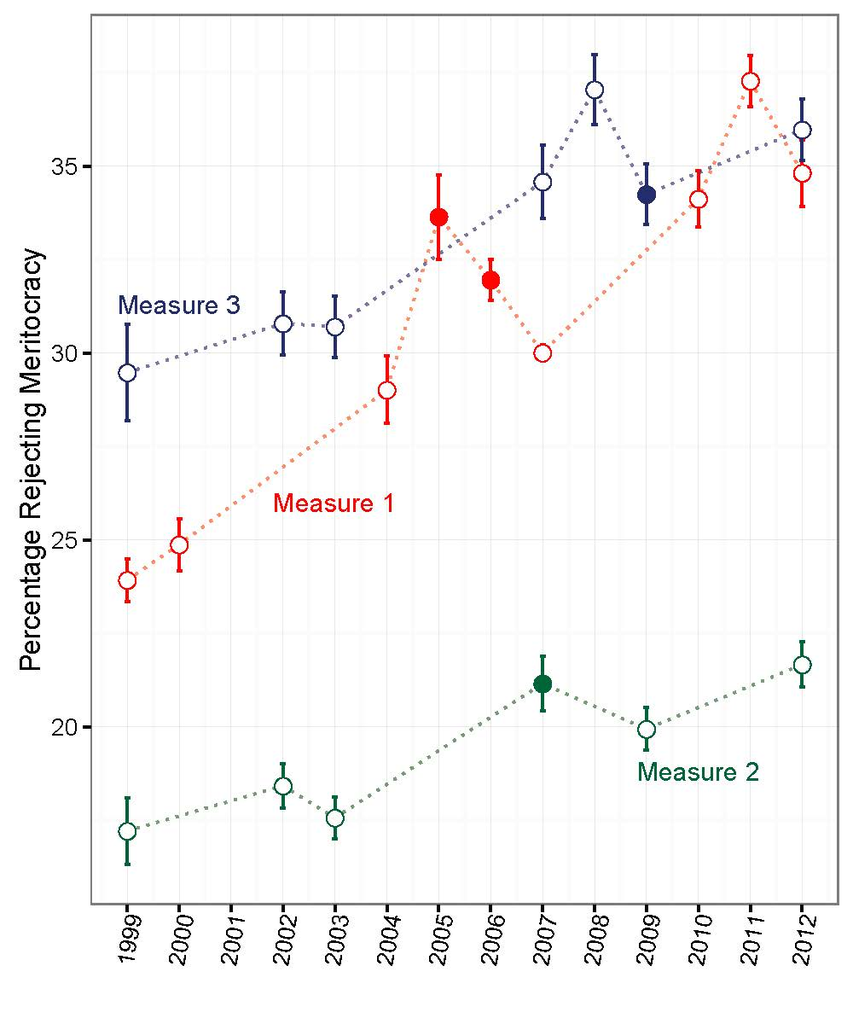

## Example: Inequality

- Income
  - Census
  - Self-report
- GINI coefficient

[figure not shown]

## Methods

## Where Does the Data Come from?

- Case:
  - Governmental archives
  - Academic paper
  - Internet
- Survey
- Statistical data

## Example: GINI coefficient

- Solt et al 2016,2017:
- SWIID: The best Gini data.

## Standardized World Income Inequality Database

- Frederick Solt, Associate Professor in Political Science, University of Iowa.

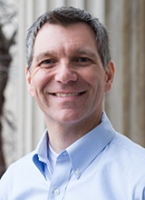

- The best GINI dataset
  - Base model: Luxembourg Income Study
  - Yearly updated
  - Website: http://fsolt.org/swiid/

## What Method Should I Use?

- Theory-driven
- Debates
  - Small-N vs. Large-N
  - Quantitative vs. Qualitative
- Process
  - Build up from a simple model
  - Select method based on the nature of data
  - Add necessary controls
  - Space and time

## Example: Solt et al. 2016

Hypothesis: Poor people living with high inequality believe in meritocracy more/less.

- Model:

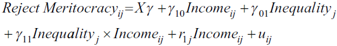

  - Ordered Logit
  - Multilevel Model
- Why Interaction?
  - How to interpret it?
  - Coefficient?
  - Correct way:

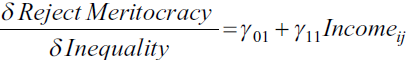

## How to Report the Results?

- Table?

[figure not shown]

- Kastellec and Leoni (2007): Plot
  - Efficient & Focused
- Example: Solt et al. 2016

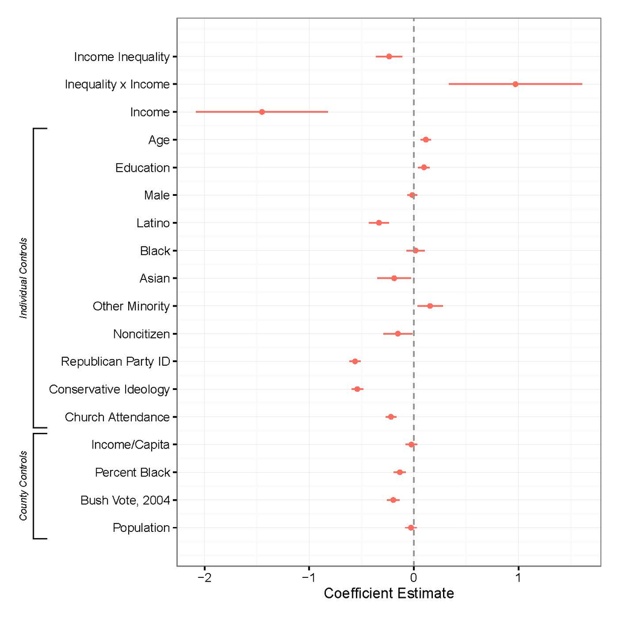

## How about Interaction

[figure not shown]

## One Step Further

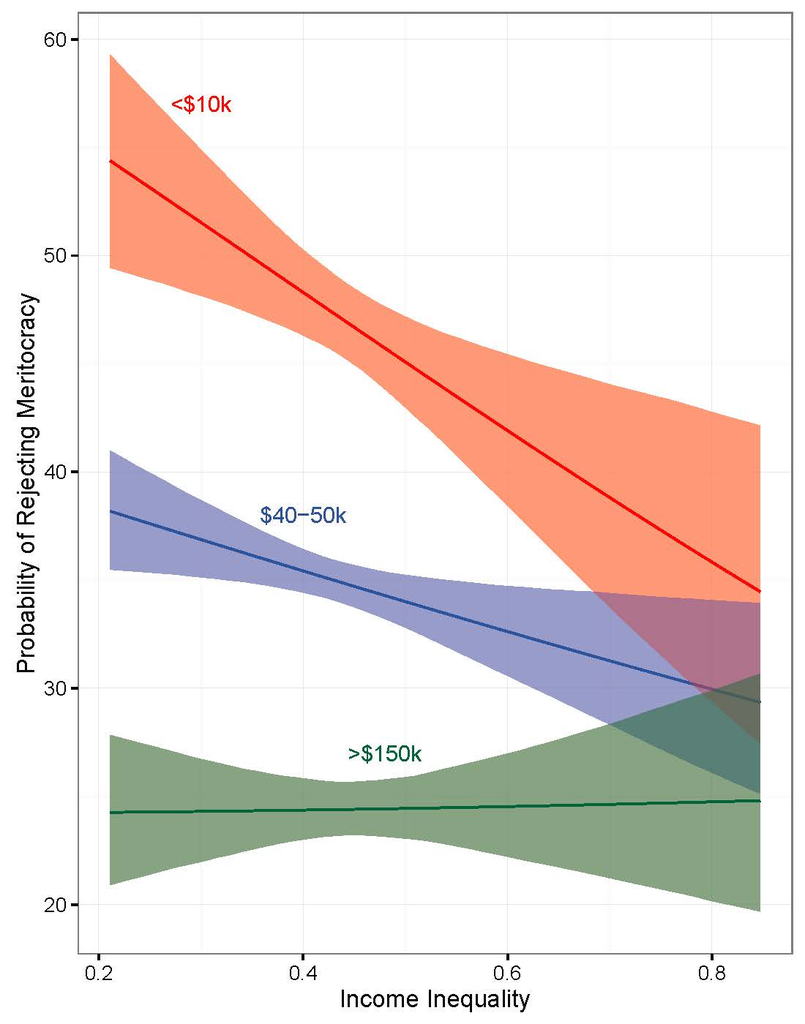

## Checklist for Research Design

- Do I have a good question?
- Do I have a developed theory?
- Do I have a set of causal hypotheses?
- Do I select appropriate measurements?
- Is my data source legit?
- Is my method legit?
- Do I present the results in the most efficient way?
- Don't forget to chat with your adviser, faculty members, and colleagues!

## Some Tips for Qualitative Fellows

## How Can I Be a Qualitative Social Scientist?

- Equivalently complex (if not more)!
- Be scientific! (see Przeworski and Teune 1970)
- Method section! (process tracing, thick description, case comparison……).
- Incorporate numbers!
- Visualize your data! (AtLas.ti, NVivo, Quirkos, etc.)

Coauthor with me and other quantitative scholars—WE NEED YOU!

[figure not shown]

## Where can you find the slides?

My Homepage: https://sammo3182.github.io/

## Questions?

[figure not shown]

## Class Ends…

[figure not shown]